# Risk Factor Analysis

## Outcome Variable

**Outcome Variable:** stunt24

## Predictor Variables

**Intervention Variable:** wast06

**Adjustment Set:**

unadjusted

## Stratifying Variables

The analysis was stratified on these variable(s):

- agecat
- studyid
- country

## Data Summary

| agecat | studyid | country | wast06 | stunt24 | n_cell | n | outcome_variable |
| --- | --- | --- | --- | --- | --- | --- | --- |
| 0-6 months | ki0047075b-MAL-ED | BANGLADESH | 0 | 0 | 88 | 263 | stunt24 |
| 0-6 months | ki0047075b-MAL-ED | BANGLADESH | 0 | 1 | 115 | 263 | stunt24 |
| 0-6 months | ki0047075b-MAL-ED | BANGLADESH | 1 | 0 | 29 | 263 | stunt24 |
| 0-6 months | ki0047075b-MAL-ED | BANGLADESH | 1 | 1 | 31 | 263 | stunt24 |
| 0-6 months | ki0047075b-MAL-ED | BRAZIL | 0 | 0 | 191 | 233 | stunt24 |
| 0-6 months | ki0047075b-MAL-ED | BRAZIL | 0 | 1 | 27 | 233 | stunt24 |
| 0-6 months | ki0047075b-MAL-ED | BRAZIL | 1 | 0 | 13 | 233 | stunt24 |
| 0-6 months | ki0047075b-MAL-ED | BRAZIL | 1 | 1 | 2 | 233 | stunt24 |
| 0-6 months | ki0047075b-MAL-ED | INDIA | 0 | 0 | 72 | 251 | stunt24 |
| 0-6 months | ki0047075b-MAL-ED | INDIA | 0 | 1 | 97 | 251 | stunt24 |
| 0-6 months | ki0047075b-MAL-ED | INDIA | 1 | 0 | 47 | 251 | stunt24 |
| 0-6 months | ki0047075b-MAL-ED | INDIA | 1 | 1 | 35 | 251 | stunt24 |
| 0-6 months | ki0047075b-MAL-ED | NEPAL | 0 | 0 | 140 | 240 | stunt24 |
| 0-6 months | ki0047075b-MAL-ED | NEPAL | 0 | 1 | 52 | 240 | stunt24 |
| 0-6 months | ki0047075b-MAL-ED | NEPAL | 1 | 0 | 33 | 240 | stunt24 |
| 0-6 months | ki0047075b-MAL-ED | NEPAL | 1 | 1 | 15 | 240 | stunt24 |
| 0-6 months | ki0047075b-MAL-ED | PERU | 0 | 0 | 154 | 302 | stunt24 |
| 0-6 months | ki0047075b-MAL-ED | PERU | 0 | 1 | 137 | 302 | stunt24 |
| 0-6 months | ki0047075b-MAL-ED | PERU | 1 | 0 | 6 | 302 | stunt24 |
| 0-6 months | ki0047075b-MAL-ED | PERU | 1 | 1 | 5 | 302 | stunt24 |
| 0-6 months | ki0047075b-MAL-ED | SOUTH AFRICA | 0 | 0 | 153 | 312 | stunt24 |
| 0-6 months | ki0047075b-MAL-ED | SOUTH AFRICA | 0 | 1 | 124 | 312 | stunt24 |
| 0-6 months | ki0047075b-MAL-ED | SOUTH AFRICA | 1 | 0 | 22 | 312 | stunt24 |
| 0-6 months | ki0047075b-MAL-ED | SOUTH AFRICA | 1 | 1 | 13 | 312 | stunt24 |
| 0-6 months | ki0047075b-MAL-ED | TANZANIA, UNITED REPUBLIC OF | 0 | 0 | 50 | 261 | stunt24 |
| 0-6 months | ki0047075b-MAL-ED | TANZANIA, UNITED REPUBLIC OF | 0 | 1 | 198 | 261 | stunt24 |
| 0-6 months | ki0047075b-MAL-ED | TANZANIA, UNITED REPUBLIC OF | 1 | 0 | 1 | 261 | stunt24 |
| 0-6 months | ki0047075b-MAL-ED | TANZANIA, UNITED REPUBLIC OF | 1 | 1 | 12 | 261 | stunt24 |
| 0-6 months | ki1000108-CMC-V-BCS-2002 | INDIA | 0 | 0 | 31 | 368 | stunt24 |
| 0-6 months | ki1000108-CMC-V-BCS-2002 | INDIA | 0 | 1 | 147 | 368 | stunt24 |

[output cut: 54 more lines]

The following strata were considered:

- agecat: 0-6 months, studyid: ki0047075b-MAL-ED, country: BANGLADESH
- agecat: 0-6 months, studyid: ki0047075b-MAL-ED, country: BRAZIL
- agecat: 0-6 months, studyid: ki0047075b-MAL-ED, country: INDIA
- agecat: 0-6 months, studyid: ki0047075b-MAL-ED, country: NEPAL
- agecat: 0-6 months, studyid: ki0047075b-MAL-ED, country: PERU
- agecat: 0-6 months, studyid: ki0047075b-MAL-ED, country: SOUTH AFRICA
- agecat: 0-6 months, studyid: ki0047075b-MAL-ED, country: TANZANIA, UNITED REPUBLIC OF
- agecat: 0-6 months, studyid: ki1000108-CMC-V-BCS-2002, country: INDIA
- agecat: 0-6 months, studyid: ki1000108-IRC, country: INDIA
- agecat: 0-6 months, studyid: ki1000109-EE, country: PAKISTAN
- agecat: 0-6 months, studyid: ki1000109-ResPak, country: PAKISTAN
- agecat: 0-6 months, studyid: ki1017093b-PROVIDE, country: BANGLADESH
- agecat: 0-6 months, studyid: ki1066203-TanzaniaChild2, country: TANZANIA, UNITED REPUBLIC OF
- agecat: 0-6 months, studyid: ki1101329-Keneba, country: GAMBIA
- agecat: 0-6 months, studyid: ki1112895-Guatemala BSC, country: GUATEMALA
- agecat: 0-6 months, studyid: ki1113344-GMS-Nepal, country: NEPAL
- agecat: 0-6 months, studyid: ki1114097-CMIN, country: BANGLADESH
- agecat: 0-6 months, studyid: ki1114097-CONTENT, country: PERU
- agecat: 18-24 months, studyid: ki1000108-CMC-V-BCS-2002, country: INDIA
- agecat: 18-24 months, studyid: ki1000108-IRC, country: INDIA
- agecat: 18-24 months, studyid: ki1101329-Keneba, country: GAMBIA

### Dropped Strata

Some strata were dropped due to rare outcomes:

- agecat: 0-6 months, studyid: ki0047075b-MAL-ED, country: BRAZIL
- agecat: 0-6 months, studyid: ki0047075b-MAL-ED, country: TANZANIA, UNITED REPUBLIC OF
- agecat: 0-6 months, studyid: ki1112895-Guatemala BSC, country: GUATEMALA
- agecat: 0-6 months, studyid: ki1114097-CONTENT, country: PERU
- agecat: 18-24 months, studyid: ki1000108-CMC-V-BCS-2002, country: INDIA
- agecat: 18-24 months, studyid: ki1000108-IRC, country: INDIA

## Methods Detail

We’re interested in the causal parameters $E[Y_a]$ for all values of $a \in \mathcal{A}$. These parameters represent the mean outcome if, possibly contrary to fact, we intervened to set all units to have $A=a$. Under the randomization and positivity assumptions, these are identified by the statistical parameters $\psi_a=E_W[E_{Y|A,W}(Y|A=a,W)]$. In addition, we’re interested in the mean of $Y$, $E[Y]$ under no intervention (the observed mean). We will estimate these parameters by using SuperLearner to fit the relevant likelihood factors – $E_{Y|A,W}(Y|A=a,W)$ and $p(A=a|W)$, and then updating our likelihood fit using a joint TMLE.

For unadjusted analyses ($W=\{\}$), initial likelihoods were estimated using Lrnr_glm to estimate the simple $E(Y|A)$ and Lrnr_mean to estimate $p(A)$. For adjusted analyses, a small library containing Lrnr_glmnet, Lrnr_xgboost, and Lrnr_mean was used.

Having estimated these parameters, we will then use the delta method to estimate relative risks and attributable risks relative to a prespecified baseline level of $A$.

# Results Detail

## Results Plots

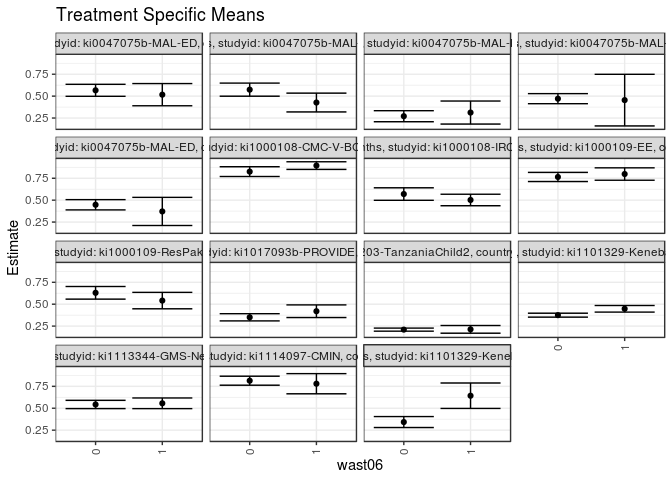

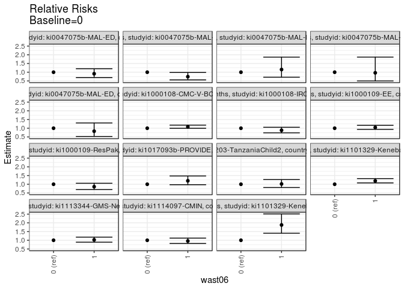

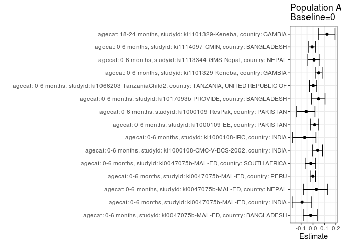

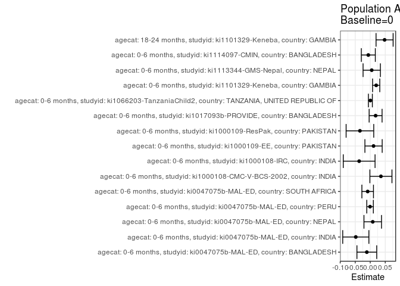

## Results Table

### Parameter: TSM

| agecat | studyid | country | intervention_level | baseline_level | estimate | ci_lower | ci_upper |
| --- | --- | --- | --- | --- | --- | --- | --- |
| 0-6 months | ki0047075b-MAL-ED | BANGLADESH | 0 | NA | 0.5665025 | 0.4982023 | 0.6348026 |
| 0-6 months | ki0047075b-MAL-ED | BANGLADESH | 1 | NA | 0.5166667 | 0.3899808 | 0.6433526 |
| 0-6 months | ki0047075b-MAL-ED | INDIA | 0 | NA | 0.5739645 | 0.4992617 | 0.6486673 |
| 0-6 months | ki0047075b-MAL-ED | INDIA | 1 | NA | 0.4268293 | 0.3195596 | 0.5340990 |
| 0-6 months | ki0047075b-MAL-ED | NEPAL | 0 | NA | 0.2708333 | 0.2078438 | 0.3338229 |
| 0-6 months | ki0047075b-MAL-ED | NEPAL | 1 | NA | 0.3125000 | 0.1811000 | 0.4439000 |
| 0-6 months | ki0047075b-MAL-ED | PERU | 0 | NA | 0.4707904 | 0.4133457 | 0.5282350 |
| 0-6 months | ki0047075b-MAL-ED | PERU | 1 | NA | 0.4545455 | 0.1598049 | 0.7492860 |
| 0-6 months | ki0047075b-MAL-ED | SOUTH AFRICA | 0 | NA | 0.4476534 | 0.3890015 | 0.5063053 |
| 0-6 months | ki0047075b-MAL-ED | SOUTH AFRICA | 1 | NA | 0.3714286 | 0.2110944 | 0.5317628 |
| 0-6 months | ki1000108-CMC-V-BCS-2002 | INDIA | 0 | NA | 0.8258427 | 0.7700537 | 0.8816317 |
| 0-6 months | ki1000108-CMC-V-BCS-2002 | INDIA | 1 | NA | 0.8947368 | 0.8510402 | 0.9384335 |
| 0-6 months | ki1000108-IRC | INDIA | 0 | NA | 0.5698925 | 0.4986551 | 0.6411299 |
| 0-6 months | ki1000108-IRC | INDIA | 1 | NA | 0.5022422 | 0.4365380 | 0.5679463 |
| 0-6 months | ki1000109-EE | PAKISTAN | 0 | NA | 0.7647059 | 0.7125739 | 0.8168379 |
| 0-6 months | ki1000109-EE | PAKISTAN | 1 | NA | 0.7983871 | 0.7276777 | 0.8690965 |
| 0-6 months | ki1000109-ResPak | PAKISTAN | 0 | NA | 0.6300578 | 0.5579880 | 0.7021276 |
| 0-6 months | ki1000109-ResPak | PAKISTAN | 1 | NA | 0.5412844 | 0.4475734 | 0.6349954 |
| 0-6 months | ki1017093b-PROVIDE | BANGLADESH | 0 | NA | 0.3506744 | 0.3095918 | 0.3917570 |
| 0-6 months | ki1017093b-PROVIDE | BANGLADESH | 1 | NA | 0.4198895 | 0.3479376 | 0.4918414 |
| 0-6 months | ki1066203-TanzaniaChild2 | TANZANIA, UNITED REPUBLIC OF | 0 | NA | 0.2098885 | 0.1923122 | 0.2274648 |
| 0-6 months | ki1066203-TanzaniaChild2 | TANZANIA, UNITED REPUBLIC OF | 1 | NA | 0.2132132 | 0.1692133 | 0.2572132 |
| 0-6 months | ki1101329-Keneba | GAMBIA | 0 | NA | 0.3750000 | 0.3525807 | 0.3974193 |
| 0-6 months | ki1101329-Keneba | GAMBIA | 1 | NA | 0.4477612 | 0.4101007 | 0.4854217 |
| 0-6 months | ki1113344-GMS-Nepal | NEPAL | 0 | NA | 0.5431235 | 0.4959515 | 0.5902956 |
| 0-6 months | ki1113344-GMS-Nepal | NEPAL | 1 | NA | 0.5564202 | 0.4956367 | 0.6172037 |
| 0-6 months | ki1114097-CMIN | BANGLADESH | 0 | NA | 0.8144796 | 0.7631355 | 0.8658237 |
| 0-6 months | ki1114097-CMIN | BANGLADESH | 1 | NA | 0.7800000 | 0.6649665 | 0.8950335 |
| 18-24 months | ki1101329-Keneba | GAMBIA | 0 | NA | 0.3423423 | 0.2798069 | 0.4048777 |
| 18-24 months | ki1101329-Keneba | GAMBIA | 1 | NA | 0.6428571 | 0.4976708 | 0.7880435 |

### Parameter: E(Y)

| agecat | studyid | country | intervention_level | baseline_level | estimate | ci_lower | ci_upper |
| --- | --- | --- | --- | --- | --- | --- | --- |
| 0-6 months | ki0047075b-MAL-ED | BANGLADESH | NA | NA | 0.5551331 | 0.4949588 | 0.6153074 |
| 0-6 months | ki0047075b-MAL-ED | INDIA | NA | NA | 0.5258964 | 0.4640001 | 0.5877927 |
| 0-6 months | ki0047075b-MAL-ED | NEPAL | NA | NA | 0.2791667 | 0.2222947 | 0.3360386 |
| 0-6 months | ki0047075b-MAL-ED | PERU | NA | NA | 0.4701987 | 0.4138139 | 0.5265835 |
| 0-6 months | ki0047075b-MAL-ED | SOUTH AFRICA | NA | NA | 0.4391026 | 0.3839466 | 0.4942585 |
| 0-6 months | ki1000108-CMC-V-BCS-2002 | INDIA | NA | NA | 0.8614130 | 0.8260637 | 0.8967624 |
| 0-6 months | ki1000108-IRC | INDIA | NA | NA | 0.5330073 | 0.4845968 | 0.5814178 |
| 0-6 months | ki1000109-EE | PAKISTAN | NA | NA | 0.7757256 | 0.7336775 | 0.8177737 |
| 0-6 months | ki1000109-ResPak | PAKISTAN | NA | NA | 0.5957447 | 0.5383657 | 0.6531237 |
| 0-6 months | ki1017093b-PROVIDE | BANGLADESH | NA | NA | 0.3685714 | 0.3328086 | 0.4043343 |
| 0-6 months | ki1066203-TanzaniaChild2 | TANZANIA, UNITED REPUBLIC OF | NA | NA | 0.2103506 | 0.1940282 | 0.2266730 |
| 0-6 months | ki1101329-Keneba | GAMBIA | NA | NA | 0.3948010 | 0.3754888 | 0.4141131 |
| 0-6 months | ki1113344-GMS-Nepal | NEPAL | NA | NA | 0.5481050 | 0.5108355 | 0.5853744 |
| 0-6 months | ki1114097-CMIN | BANGLADESH | NA | NA | 0.8081181 | 0.7611481 | 0.8550881 |
| 18-24 months | ki1101329-Keneba | GAMBIA | NA | NA | 0.3901515 | 0.3311996 | 0.4491034 |

### Parameter: RR

| agecat | studyid | country | intervention_level | baseline_level | estimate | ci_lower | ci_upper |
| --- | --- | --- | --- | --- | --- | --- | --- |
| 0-6 months | ki0047075b-MAL-ED | BANGLADESH | 0 | 0 | 1.0000000 | 1.0000000 | 1.0000000 |
| 0-6 months | ki0047075b-MAL-ED | BANGLADESH | 1 | 0 | 0.9120290 | 0.6939746 | 1.1985984 |
| 0-6 months | ki0047075b-MAL-ED | INDIA | 0 | 0 | 1.0000000 | 1.0000000 | 1.0000000 |
| 0-6 months | ki0047075b-MAL-ED | INDIA | 1 | 0 | 0.7436510 | 0.5603447 | 0.9869226 |
| 0-6 months | ki0047075b-MAL-ED | NEPAL | 0 | 0 | 1.0000000 | 1.0000000 | 1.0000000 |
| 0-6 months | ki0047075b-MAL-ED | NEPAL | 1 | 0 | 1.1538462 | 0.7136126 | 1.8656635 |
| 0-6 months | ki0047075b-MAL-ED | PERU | 0 | 0 | 1.0000000 | 1.0000000 | 1.0000000 |
| 0-6 months | ki0047075b-MAL-ED | PERU | 1 | 0 | 0.9654944 | 0.4991121 | 1.8676755 |
| 0-6 months | ki0047075b-MAL-ED | SOUTH AFRICA | 0 | 0 | 1.0000000 | 1.0000000 | 1.0000000 |
| 0-6 months | ki0047075b-MAL-ED | SOUTH AFRICA | 1 | 0 | 0.8297235 | 0.5284656 | 1.3027169 |
| 0-6 months | ki1000108-CMC-V-BCS-2002 | INDIA | 0 | 0 | 1.0000000 | 1.0000000 | 1.0000000 |
| 0-6 months | ki1000108-CMC-V-BCS-2002 | INDIA | 1 | 0 | 1.0834228 | 0.9967721 | 1.1776063 |
| 0-6 months | ki1000108-IRC | INDIA | 0 | 0 | 1.0000000 | 1.0000000 | 1.0000000 |
| 0-6 months | ki1000108-IRC | INDIA | 1 | 0 | 0.8812928 | 0.7354252 | 1.0560925 |
| 0-6 months | ki1000109-EE | PAKISTAN | 0 | 0 | 1.0000000 | 1.0000000 | 1.0000000 |
| 0-6 months | ki1000109-EE | PAKISTAN | 1 | 0 | 1.0440447 | 0.9336420 | 1.1675024 |
| 0-6 months | ki1000109-ResPak | PAKISTAN | 0 | 0 | 1.0000000 | 1.0000000 | 1.0000000 |
| 0-6 months | ki1000109-ResPak | PAKISTAN | 1 | 0 | 0.8591028 | 0.6981167 | 1.0572123 |
| 0-6 months | ki1017093b-PROVIDE | BANGLADESH | 0 | 0 | 1.0000000 | 1.0000000 | 1.0000000 |
| 0-6 months | ki1017093b-PROVIDE | BANGLADESH | 1 | 0 | 1.1973772 | 0.9729283 | 1.4736052 |
| 0-6 months | ki1066203-TanzaniaChild2 | TANZANIA, UNITED REPUBLIC OF | 0 | 0 | 1.0000000 | 1.0000000 | 1.0000000 |
| 0-6 months | ki1066203-TanzaniaChild2 | TANZANIA, UNITED REPUBLIC OF | 1 | 0 | 1.0158403 | 0.8130251 | 1.2692493 |
| 0-6 months | ki1101329-Keneba | GAMBIA | 0 | 0 | 1.0000000 | 1.0000000 | 1.0000000 |
| 0-6 months | ki1101329-Keneba | GAMBIA | 1 | 0 | 1.1940299 | 1.0769605 | 1.3238251 |
| 0-6 months | ki1113344-GMS-Nepal | NEPAL | 0 | 0 | 1.0000000 | 1.0000000 | 1.0000000 |
| 0-6 months | ki1113344-GMS-Nepal | NEPAL | 1 | 0 | 1.0244819 | 0.8910339 | 1.1779160 |
| 0-6 months | ki1114097-CMIN | BANGLADESH | 0 | 0 | 1.0000000 | 1.0000000 | 1.0000000 |
| 0-6 months | ki1114097-CMIN | BANGLADESH | 1 | 0 | 0.9576667 | 0.8157540 | 1.1242672 |
| 18-24 months | ki1101329-Keneba | GAMBIA | 0 | 0 | 1.0000000 | 1.0000000 | 1.0000000 |
| 18-24 months | ki1101329-Keneba | GAMBIA | 1 | 0 | 1.8778195 | 1.4044404 | 2.5107553 |

### Parameter: PAR

| agecat | studyid | country | intervention_level | baseline_level | estimate | ci_lower | ci_upper |
| --- | --- | --- | --- | --- | --- | --- | --- |
| 0-6 months | ki0047075b-MAL-ED | BANGLADESH | 0 | NA | -0.0113694 | -0.0443013 | 0.0215626 |
| 0-6 months | ki0047075b-MAL-ED | INDIA | 0 | NA | -0.0480681 | -0.0916212 | -0.0045150 |
| 0-6 months | ki0047075b-MAL-ED | NEPAL | 0 | NA | 0.0083333 | -0.0208867 | 0.0375534 |
| 0-6 months | ki0047075b-MAL-ED | PERU | 0 | NA | -0.0005917 | -0.0115347 | 0.0103513 |
| 0-6 months | ki0047075b-MAL-ED | SOUTH AFRICA | 0 | NA | -0.0085509 | -0.0278884 | 0.0107867 |
| 0-6 months | ki1000108-CMC-V-BCS-2002 | INDIA | 0 | NA | 0.0355703 | -0.0011866 | 0.0723273 |
| 0-6 months | ki1000108-IRC | INDIA | 0 | NA | -0.0368851 | -0.0898253 | 0.0160551 |
| 0-6 months | ki1000109-EE | PAKISTAN | 0 | NA | 0.0110197 | -0.0177668 | 0.0398062 |
| 0-6 months | ki1000109-ResPak | PAKISTAN | 0 | NA | -0.0343131 | -0.0802865 | 0.0116603 |
| 0-6 months | ki1017093b-PROVIDE | BANGLADESH | 0 | NA | 0.0178971 | -0.0036442 | 0.0394383 |
| 0-6 months | ki1066203-TanzaniaChild2 | TANZANIA, UNITED REPUBLIC OF | 0 | NA | 0.0004621 | -0.0061231 | 0.0070473 |
| 0-6 months | ki1101329-Keneba | GAMBIA | 0 | NA | 0.0198010 | 0.0078052 | 0.0317967 |
| 0-6 months | ki1113344-GMS-Nepal | NEPAL | 0 | NA | 0.0049814 | -0.0238473 | 0.0338101 |
| 0-6 months | ki1114097-CMIN | BANGLADESH | 0 | NA | -0.0063616 | -0.0296583 | 0.0169352 |
| 18-24 months | ki1101329-Keneba | GAMBIA | 0 | NA | 0.0478092 | 0.0193670 | 0.0762513 |

### Parameter: PAF

| agecat | studyid | country | intervention_level | baseline_level | estimate | ci_lower | ci_upper |
| --- | --- | --- | --- | --- | --- | --- | --- |
| 0-6 months | ki0047075b-MAL-ED | BANGLADESH | 0 | NA | -0.0204805 | -0.0816293 | 0.0372114 |
| 0-6 months | ki0047075b-MAL-ED | INDIA | 0 | NA | -0.0914022 | -0.1785077 | -0.0107348 |
| 0-6 months | ki0047075b-MAL-ED | NEPAL | 0 | NA | 0.0298507 | -0.0806241 | 0.1290315 |
| 0-6 months | ki0047075b-MAL-ED | PERU | 0 | NA | -0.0012584 | -0.0248045 | 0.0217467 |
| 0-6 months | ki0047075b-MAL-ED | SOUTH AFRICA | 0 | NA | -0.0194735 | -0.0645197 | 0.0236665 |
| 0-6 months | ki1000108-CMC-V-BCS-2002 | INDIA | 0 | NA | 0.0412930 | -0.0027238 | 0.0833776 |
| 0-6 months | ki1000108-IRC | INDIA | 0 | NA | -0.0692019 | -0.1735991 | 0.0259086 |
| 0-6 months | ki1000109-EE | PAKISTAN | 0 | NA | 0.0142057 | -0.0236590 | 0.0506697 |
| 0-6 months | ki1000109-ResPak | PAKISTAN | 0 | NA | -0.0575970 | -0.1381048 | 0.0172157 |
| 0-6 months | ki1017093b-PROVIDE | BANGLADESH | 0 | NA | 0.0485579 | -0.0117422 | 0.1052641 |
| 0-6 months | ki1066203-TanzaniaChild2 | TANZANIA, UNITED REPUBLIC OF | 0 | NA | 0.0021967 | -0.0296052 | 0.0330163 |
| 0-6 months | ki1101329-Keneba | GAMBIA | 0 | NA | 0.0501543 | 0.0192543 | 0.0800807 |
| 0-6 months | ki1113344-GMS-Nepal | NEPAL | 0 | NA | 0.0090884 | -0.0449349 | 0.0603187 |
| 0-6 months | ki1114097-CMIN | BANGLADESH | 0 | NA | -0.0078721 | -0.0371447 | 0.0205744 |
| 18-24 months | ki1101329-Keneba | GAMBIA | 0 | NA | 0.1225400 | 0.0462128 | 0.1927591 |